# Federal Election 2025: Sample and Descriptives

The PTV item of each party.

```r
ptv_col_by_party_federal <- c(
  "AfD"     = "ptv_afd",
  "BSW"     = "ptv_bsw",
  "CDU/CSU" = "ptv_cdu",
  "FDP"     = "ptv_fdp",
  "Greens"  = "ptv_gruene",
  "Left"    = "ptv_linke",
  "SPD"     = "ptv_spd"
)
```

Data of `21_federal_data_preparation.Rmd`: one row per respondent, one row per respondent and party, and the official result.

```r
load("data/processed/data_federal.rdata")
load("data/processed/data_federal_long.rdata")
load("data/processed/results_official_federal.rdata")
```

# Data

## Exclusion of Satisficers

Respondents who allocated 50% (the slider maximum) to two parties are excluded as satisficers (paper section Data). For each respondent, the number of sliders set to 50 is counted, and respondents with two or more are flagged as `excluded`. Two data sets are kept for every later step:

- `data_federal_main`: the analytic sample, without the excluded respondents,
- `data_federal_noexcl`: all respondents, for the robustness checks without exclusions.

The same split is also made for the long data (one row per respondent and party).

```r
list_votes_exp_vars_federal <- c(
  "list_votes_exp_cdu", "list_votes_exp_afd", "list_votes_exp_linke",
  "list_votes_exp_gruene", "list_votes_exp_spd", "list_votes_exp_fdp",
  "list_votes_exp_bsw", "list_votes_exp_other"
)
data_federal_noexcl <- data_federal %>%
  mutate(
    n_50 = rowSums(across(all_of(list_votes_exp_vars_federal)) == 50),
    excluded = n_50 >= 2,
    excl_reason = if_else(excluded, "answered 50 twice", "included")
  ) %>%
  select(-n_50)

data_federal_long_noexcl <- data_federal_long %>%
  left_join(data_federal_noexcl %>% select(ResponseId, excluded, excl_reason, zs_int), by = "ResponseId")

data_federal_main <- data_federal_noexcl %>% filter(!excluded)
data_federal_long_main <- data_federal_long_noexcl %>% filter(!excluded)
```

Recruited, excluded and analytic sample.

```r
data_federal_noexcl %>%
  summarize(recruited = n(), analytic = sum(!excluded), excluded = sum(excluded))
```

```
# A tibble: 1 × 3
  recruited analytic excluded
      <int>    <int>    <int>
1     29195    28430      765
```

```r
rm(data_federal, data_federal_long)
```

## Benchmarks for the Sample Composition

The sample composition table (Table B.3) compares the sample with benchmarks from official statistics.

Eligible voters by gender, birth cohort and state, from the representative electoral statistics of the Federal Returning Officer (`btw25_rws_bw2.csv`). Birth cohorts are grouped into the age groups of the survey, and men include diverse and other voters (`m|d|o`), as Men* in the survey.

```r
data_federal_returning_officer <- read_delim("data/input/benchmark/btw25_rws_bw2.csv",
  delim = ";", escape_double = FALSE, trim_ws = TRUE # the file is semicolon-separated
) %>%
  set_names(c(
    "Land", "Geschlecht", "Geburtsjahresgruppe", "Wahlberechtigte",
    "Wahlberechtigte ohne Wahlscheinvermerk", "Wahlberechtigte mit Wahlscheinvermerk",
    "Wählende", "Wählende ohne Wahlschein", "Wählende mit Wahlschein", "Wahlbeteiligung"
  ))

df_fro_gender_age_federal <- data_federal_returning_officer %>%
  filter(Land == "Bund", Geschlecht != "Summe", Geburtsjahresgruppe != "Summe") %>%
  mutate(
    age_group = case_when(
      Geburtsjahresgruppe %in% c("2005-2007", "2001-2004", "1996-2000") ~ "18-29",
      Geburtsjahresgruppe %in% c("1991-1995", "1986-1990") ~ "30-39",
      Geburtsjahresgruppe %in% c("1981-1985", "1976-1980") ~ "40-49",
      Geburtsjahresgruppe == "1966-1975" ~ "50-59",
      Geburtsjahresgruppe %in% c("1956-1965", "<=1955") ~ "60+",
      TRUE ~ NA_character_
    ),
    gender = case_when(
      Geschlecht == "m|d|o" ~ "Men",
      Geschlecht == "w" ~ "Women",
      TRUE ~ NA_character_
    ),
    Wahlberechtigte = as.numeric(Wahlberechtigte)
  ) %>%
  filter(!is.na(gender)) %>%
  group_by(age_group, gender) %>%
  summarize(Wahlberechtigte = sum(Wahlberechtigte, na.rm = TRUE), .groups = "drop")

# Totals by gender over all age groups
df_fro_gender_age_federal <- df_fro_gender_age_federal %>%
  bind_rows(
    df_fro_gender_age_federal %>%
      group_by(gender) %>%
      summarize(Wahlberechtigte = sum(Wahlberechtigte), .groups = "drop") %>%
      mutate(age_group = "Insgesamt")
  )

df_fro_age_federal <- df_fro_gender_age_federal %>%
  filter(age_group != "Insgesamt") %>%
  pivot_wider(names_from = gender, values_from = Wahlberechtigte) %>%
  mutate(
    eligible_age_group = Men + Women,
    eligible_total     = sum(eligible_age_group),
    benchmark          = eligible_age_group / eligible_total
  )

df_fro_gender_federal <- df_fro_gender_age_federal %>%
  filter(age_group == "Insgesamt") %>%
  select(-age_group) %>%
  rename(eligible_gender_group = Wahlberechtigte) %>%
  mutate(
    eligible_total = sum(eligible_gender_group),
    benchmark      = eligible_gender_group / eligible_total
  )

df_fro_states_federal <- data_federal_returning_officer %>%
  filter(Land != "Bund", Geschlecht == "Summe", Geburtsjahresgruppe == "Summe") %>%
  select(Land, Wahlberechtigte) %>%
  mutate(Land = case_match(
    Land,
    "BW" ~ "Baden-Württemberg",
    "BY" ~ "Bavaria",
    "BE" ~ "Berlin",
    "BB" ~ "Brandenburg",
    "HB" ~ "Bremen",
    "HH" ~ "Hamburg",
    "HE" ~ "Hesse",
    "MV" ~ "Mecklenburg-Western Pomerania",
    "NI" ~ "Lower Saxony",
    "NW" ~ "North Rhine-Westphalia",
    "RP" ~ "Rhineland-Palatinate",
    "SL" ~ "Saarland",
    "SN" ~ "Saxony",
    "ST" ~ "Saxony-Anhalt",
    "SH" ~ "Schleswig-Holstein",
    "TH" ~ "Thuringia"
  )) %>%
  rename(eligible_state = Wahlberechtigte, bula = Land) %>%
  mutate(
    eligible_state = as.numeric(eligible_state),
    eligible_total = sum(eligible_state),
    benchmark      = eligible_state / eligible_total
  ) %>%
  select(bula, benchmark)
```

Benchmark of the vote intention: the election result, with CDU and CSU separately, because the survey asked for them separately.

```r
# Second votes of CDU and CSU, as shares of the valid second votes
votes_federal <- read_csv("data/input/results/btw25_second_votes_federal.csv", show_col_types = FALSE)
valid_second_votes_federal <- votes_federal %>% filter(party == "Valid second votes") %>% pull(votes)
cdu_csu_benchmark_federal <- votes_federal %>%
  filter(party %in% c("CDU", "CSU")) %>%
  transmute(party, benchmark = votes / valid_second_votes_federal)

zs_benchmark_federal <- results_official_federal %>%
  mutate(
    party = if_else(party == "Others", "Other", party),
    benchmark = result_official / 100
  ) %>%
  select(-result_official) %>%
  filter(party != "CDU/CSU") %>%
  bind_rows(cdu_csu_benchmark_federal)
rm(votes_federal, valid_second_votes_federal, cdu_csu_benchmark_federal)
```

Benchmark of education: the school-leaving qualification of the population (Mikrozensus, GENESIS table 12211-0100). The qualifications are grouped into the three levels of the survey (Low, Medium, High) plus “Still in School”.

```r
df_census_age_educ_federal <- read_excel("data/input/benchmark/12211-0100_de_2025.xlsx") %>%
  set_names(c(
    "gender", "age_group", "Noch in schulischer Ausbildung", "Haupt- (Volks-)schulabschluss",
    "Abschluss der polytechnischen Oberschule", "Realschule oder gleichwertiger Abschluss",
    "Fachhochschul- oder Hochschulreife", "Ohne Angabe zur Art des Abschlusses",
    "Ohne allgemeinen Schulabschluss", "Insgesamt"
  ))

df_census_educ_federal <- df_census_age_educ_federal %>%
  drop_na("age_group") %>%
  fill(gender, .direction = "down") %>%
  filter(gender == "Insgesamt", age_group == "Insgesamt") %>%
  select(-age_group, gender) %>%
  mutate(across(.cols = everything(), .fns = ~ as.numeric(.)),
    Low = `Haupt- (Volks-)schulabschluss` + `Ohne allgemeinen Schulabschluss`,
    Medium = `Realschule oder gleichwertiger Abschluss` + `Abschluss der polytechnischen Oberschule`,
    High = `Fachhochschul- oder Hochschulreife`,
    `Still in School` = `Noch in schulischer Ausbildung`,
    census_total = Insgesamt * 1000
  ) %>%
  select(Low, Medium, High, `Still in School`, census_total) %>%
  pivot_longer(cols = Low:`Still in School`, names_to = "education_eng", values_to = "pop_clean") %>%
  mutate(pop_clean = pop_clean * 1000, benchmark = pop_clean / census_total) %>%
  select(education_eng, benchmark)
```

## Response Times

The H1 model controls for each respondent’s general speed in the survey. This baseline speed is the log of the mean response time of five filler items (birth year, vote intention, eligibility, turnout intention, political interest). Item times more than two standard deviations from the item mean are left out of this mean.

Response times of the expectation item more than two standard deviations above the mean are outliers and removed from the H1 models (paper section Modeling). Since the lower cutoff (mean - 2 SD) is negative, no response time is removed at the bottom.

```r
data_federal_time_main <- add_baseline_speed(data_federal_main) # helper
data_federal_time_noexcl <- add_baseline_speed(data_federal_noexcl) # helper

t_mean_federal <- mean(data_federal_time_main$t_list_votes_exp_Page_Submit, na.rm = TRUE)
t_threshold_upper_federal <- compute_time_cutoff(data_federal_time_main$t_list_votes_exp_Page_Submit) # helper

# No response lies more than 2 SD below the mean
data_federal_time_main %>%
  summarize(lower_cutoff_below_zero = mean(t_list_votes_exp_Page_Submit) - 2 * sd(t_list_votes_exp_Page_Submit) < 0)
```

```
# A tibble: 1 × 1
  lower_cutoff_below_zero
  <lgl>
1 TRUE
```

```r
data_federal_time_main <- data_federal_time_main %>%
  mutate(t_outlier = t_list_votes_exp_Page_Submit > t_threshold_upper_federal)

data_federal_time_main_nooutliers <- data_federal_time_main %>% filter(!t_outlier)
```

Response times before outlier removal (paper section Modeling and note of Figure B.1).

```r
data_federal_time_main %>%
  summarize(
    n = n(),
    min = min(t_list_votes_exp_Page_Submit),
    max = max(t_list_votes_exp_Page_Submit),
    mean = mean(t_list_votes_exp_Page_Submit),
    sd = sd(t_list_votes_exp_Page_Submit),
    cutoff = t_threshold_upper_federal,
    n_removed = sum(t_outlier),
    n_after_removal = sum(!t_outlier)
  ) %>%
  print_values(digits = 1) # helper
```

```
     n min     max mean    sd cutoff n_removed n_after_removal
 28430 2.7 20496.6 66.9 173.8  414.4       144           28286
```

## Preferred Party (PTV, Vote Intention, Party Identification)

H3 compares the forecast error for the respondent’s preferred party with that for the other parties. The preferred party is the party with the highest propensity to vote (PTV). Respondents who give their highest PTV to more than one party have no clearly preferred party and are removed (paper section Modeling).

Alternative measures (robustness checks):

- PTV dummy, but allowing ties (all parties with the highest PTV count as preferred),
- vote intention,
- party identification (from the re-interviews of wave 2),
- the PTV score of each party (1-11) instead of a dummy.

First, the party (or the tied parties, comma-separated) with the highest PTV of each respondent.

```r
data_federal_ptvtop_noexcl <- add_ptv_top(data_federal_noexcl, ptv_col_by_party_federal) # helper
data_federal_ptvtop_main <- data_federal_ptvtop_noexcl %>% filter(!excluded)
```

Respondents with no PTV at all, with a tied highest PTV and with a clearly preferred party.

```r
data_federal_ptvtop_main %>%
  summarize(
    no_ptv = nrow(data_federal_main) - n(),
    tied = sum(str_detect(preferred_party, ",")),
    clear = sum(!str_detect(preferred_party, ","))
  )
```

```
# A tibble: 1 × 3
  no_ptv  tied clear
   <int> <int> <int>
1     20  5354 23056
```

The clearly preferred party (PTV, without ties) is added to the long data. Respondents with tied PTVs get `NA`.

```r
data_federal_long_noexcl <- data_federal_long_noexcl %>%
  left_join(
    data_federal_ptvtop_noexcl %>%
      filter(!str_detect(preferred_party, ",")) %>%
      select(ResponseId, preferred_party),
    by = "ResponseId"
  )
data_federal_long_main <- data_federal_long_noexcl %>% filter(!excluded)
```

For every measure, a dummy in the long data: 1 if the party of the row is the respondent’s preferred party, 0 if not. *Others* is left out, since it is no party one can prefer. The PTV score of the party of each row is added as well.

```r
pref_long_federal <- create_pref_long_data(
  data_federal_long_noexcl, data_federal_ptvtop_noexcl, # helper
  ptv_col_by_party_federal, parties_7_federal
)
```

The model data of the H3 models, one data set per measure, for the main sample and without exclusions. Each keeps the rows with a non-missing value on its measure. The table shows the number of respondents and rows (respondent × party) per measure in the main sample.

```r
subsets_federal_main <- create_pref_model_data(pref_long_federal %>% filter(!excluded) %>% select(-excluded)) # helper
data_federal_ptv_main <- subsets_federal_main$ptv
data_federal_vi_main <- subsets_federal_main$vi
data_federal_pid_main <- subsets_federal_main$pid
data_federal_ptvscore_main <- subsets_federal_main$ptvscore
data_federal_ptvties_main <- subsets_federal_main$ptvties

subsets_federal_noexcl <- create_pref_model_data(pref_long_federal %>% select(-excluded)) # helper
data_federal_ptv_noexcl <- subsets_federal_noexcl$ptv
data_federal_vi_noexcl <- subsets_federal_noexcl$vi
data_federal_pid_noexcl <- subsets_federal_noexcl$pid
data_federal_ptvscore_noexcl <- subsets_federal_noexcl$ptvscore
data_federal_ptvties_noexcl <- subsets_federal_noexcl$ptvties

subsets_federal_main %>%
  map_dfr(~ summarize(.x, respondents = n_distinct(ResponseId), rows = n()), .id = "measure")
```

```
# A tibble: 5 × 3
  measure  respondents   rows
  <chr>          <int>  <int>
1 ptv            23056 160290
2 ptvties        28410 198870
3 vi             24296 170072
4 pid            10499  73493
5 ptvscore       28410 197547
```

For the descriptives of the preferred party: one row per respondent, the row of the preferred party, per measure.

```r
data_federal_prefparty_ptv_main <- create_pref_party_data(data_federal_long_main, "preferred_party", parties_7_federal) # helper
data_federal_prefparty_vi_main <- create_pref_party_data(data_federal_long_main, "zs_int", parties_7_federal) # helper
data_federal_prefparty_pid_main <- create_pref_party_data(data_federal_long_main, "pid", parties_7_federal) # helper

rm(pref_long_federal, subsets_federal_main, subsets_federal_noexcl, data_federal_ptvtop_noexcl)
```

# Sample

Size and field period of the analytic sample (paper section Data).

```r
data_federal_main %>%
  summarize(n = n(), first_day = min(interview_date), last_day = max(interview_date))
```

```
# A tibble: 1 × 3
      n first_day  last_day
  <int> <date>     <date>
1 28430 2025-01-24 2025-02-21
```

Commitment pledge not to consult outside sources (%).

```r
data_federal_noexcl %>%
  count(pledge_expectations) %>%
  mutate(pct = 100 * n / sum(n)) %>%
  print_values() # helper
```

```
              pledge_expectations     n   pct
 Nein, ich bin nicht dazu bereit.   147  0.50
              Ja, ich bin bereit. 28947 99.15
                             <NA>   101  0.35
```

## Sample Composition (Table B.3)

Sample before exclusions compared with the electorate (left) and change through the exclusions (right). First, the benchmark of every category of the table.

```r
df_benchmark_raw_federal <- bind_rows(
  compute_group_shares(data_federal_main, "age_group", "Age Group", election = "federal") %>% # helper
    left_join(df_fro_age_federal %>% select(age_group, benchmark), by = c("category" = "age_group")),
  compute_group_shares(data_federal_main, "gender_eng2", "Gender", election = "federal") %>% # helper
    left_join(df_fro_gender_federal %>% select(gender, benchmark), by = c("category" = "gender")) %>%
    mutate(category = if_else(category == "Men", "Men*", category)),
  compute_group_shares(data_federal_main, "education_eng", "Education", election = "federal") %>% # helper
    left_join(df_census_educ_federal, by = c("category" = "education_eng")),
  compute_group_shares(data_federal_main, "turnout_int_eng", "Turnout Intention", election = "federal") %>% # helper
    filter(category == "Yes") %>%
    mutate(benchmark = 0.825),
  compute_group_shares(data_federal_main, "list_vote_int_eng", "Vote Intention", election = "federal") %>% # helper
    left_join(zs_benchmark_federal, by = c("category" = "party")),
  compute_group_shares(data_federal_main, "bula_en", "State", election = "federal") %>% # helper
    left_join(df_fro_states_federal, by = c("category" = "bula"))
)

df_benchmark_raw_federal %>%
  transmute(variable, category, benchmark_pct = 100 * benchmark) %>%
  print_values(digits = 1) # helper
```

```
          variable                      category benchmark_pct
         Age Group                         18-29          13.0
         Age Group                         30-39          13.8
         Age Group                         40-49          14.2
         Age Group                         50-59          16.5
         Age Group                           60+          42.6
            Gender                          Men*          48.6
            Gender                         Women          51.4
         Education                           Low          29.7
         Education                        Medium          29.4
         Education                          High          37.2
         Education               Still in School           3.6
 Turnout Intention                           Yes          82.5
    Vote Intention                           AfD          20.8
    Vote Intention                           BSW           5.0
    Vote Intention                           CDU          22.6
    Vote Intention                           CSU           6.0
    Vote Intention                           FDP           4.3
    Vote Intention                        Greens          11.6
    Vote Intention                          Left           8.8
    Vote Intention                           SPD          16.4
    Vote Intention                         Other           4.6
             State             Baden-Württemberg          12.6
             State                       Bavaria          15.7
             State                        Berlin           4.0
             State                   Brandenburg           3.4
             State                        Bremen           0.7
             State                       Hamburg           2.1
             State                         Hesse           7.2
             State                  Lower Saxony          10.0
             State Mecklenburg-Western Pomerania           2.1
             State        North Rhine-Westphalia          21.3
             State          Rhineland-Palatinate           5.0
             State                      Saarland           1.2
             State                        Saxony           5.3
             State                 Saxony-Anhalt           2.9
             State            Schleswig-Holstein           3.7
             State                     Thuringia           2.7
```

The table: shares in the sample before exclusions with the difference to the benchmark, and shares in the main sample with the change through the exclusions, overall and by experimental group. It is written to LaTeX and shown here as HTML.

```r
balance_specs_federal <- tribble(
  ~var,                ~label,
  "age_group",         "Age Group",
  "gender_eng2",       "Gender",
  "education_eng",     "Education",
  "turnout_int_eng",   "Turnout Intention",
  "list_vote_int_eng", "Vote Intention",
  "bula_en",           "State"
)

balance_groups_federal <- c(
  full = "All",
  control = "C",
  t5 = "T(5)",
  t500 = "T(500)"
)

df_balance_federal <- compute_balance_shares(data_federal_noexcl, balance_specs_federal, election = "federal") %>% # helper
  rename_with(~ sub("^share_", "before_", .x), starts_with("share_")) %>%
  full_join(
    compute_balance_shares(data_federal_main, balance_specs_federal, election = "federal") %>% # helper
      rename_with(~ sub("^share_", "main_", .x), starts_with("share_")),
    by = c("variable", "category")
  ) %>%
  mutate(across(starts_with(c("before_", "main_")), ~ coalesce(.x, 0))) %>%
  left_join(df_benchmark_raw_federal %>% select(variable, category, benchmark), by = c("variable", "category"))

note_balance_federal <- paste0(
  "Note: Cells show the share of respondents (\\%) before exclusions (left) and in the main ",
  "sample (right), overall and by experimental group. In the main sample, ",
  format(nrow(data_federal_noexcl) - nrow(data_federal_main), big.mark = ","),
  " respondents who answered 50\\% twice are excluded. ",
  "For the overall sample, the difference to a benchmark is shown in percentage points in ",
  "parentheses. For the main sample, the difference to the overall sample before exclusions ",
  "is shown. Darker shading indicates larger absolute differences (scale up to 20 ",
  "percentage points on the left and up to 5 percentage points on the right). ",
  "Benchmarks are the eligible voting population for age, gender, ",
  "and federal state \\parencite{thefederalreturningofficerBundestagElection20252025}, ",
  "the German population for education \\parencite{GENESISOnlineTabelleBevolkerung}, ",
  "election results for vote intention, and actual turnout for turnout intention ",
  "\\parencite{thefederalreturningofficerResultsGermany2025}. ",
  "Men* includes men and diverse respondents."
)

write_balance_table( # helper
  data = df_balance_federal,
  groups = balance_groups_federal,
  n_before = count_by_group(data_federal_noexcl, election = "federal"), # helper
  n_main = count_by_group(data_federal_main, election = "federal"), # helper
  caption = "Demographic Composition of the Federal Sample (Before and After Exclusions)",
  label = "tab:balance_table_federal",
  note = note_balance_federal,
  file = "output/tables/table_B3_balance_demographics_federal.tex"
)
```

Demographic Composition of the Federal Sample (Before and After Exclusions)

|  | Bench- mark | Before Exclusions (Difference to Benchmark) All n = 29,195 | Before Exclusions (Difference to Benchmark) C n = 9,697 | Before Exclusions (Difference to Benchmark) T(5) n = 9,728 | Before Exclusions (Difference to Benchmark) T(500) n = 9,770 | Main Sample (Difference to Before Exclusions) All n = 28,430 (-765) | Main Sample (Difference to Before Exclusions) C n = 9,400 (-297) | Main Sample (Difference to Before Exclusions) T(5) n = 9,475 (-253) | Main Sample (Difference to Before Exclusions) T(500) n = 9,555 (-215) |
| --- | --- | --- | --- | --- | --- | --- | --- | --- | --- |
| Age Group |  |  |  |  |  |  |  |  |  |
| 18-29 | 13.0 | 13.1 (+0.1) | 13.1 (+0.1) | 13.2 (+0.3) | 13.0 (0.0) | 13.0 (-0.1) | 13.0 (0.0) | 13.2 (-0.1) | 12.9 (-0.1) |
| 30-39 | 13.8 | 19.9 (+6.1) | 20.0 (+6.2) | 20.2 (+6.4) | 19.5 (+5.7) | 19.7 (-0.2) | 19.8 (-0.2) | 20.0 (-0.2) | 19.4 (-0.1) |
| 40-49 | 14.2 | 20.3 (+6.1) | 20.5 (+6.4) | 20.4 (+6.3) | 19.9 (+5.7) | 20.1 (-0.1) | 20.4 (-0.1) | 20.3 (-0.1) | 19.7 (-0.2) |
| 50-59 | 16.5 | 21.3 (+4.8) | 20.7 (+4.2) | 21.5 (+5.0) | 21.6 (+5.2) | 21.4 (+0.1) | 20.7 (+0.1) | 21.6 (+0.1) | 21.8 (+0.1) |
| 60+ | 42.6 | 25.4 (-17.2) | 25.7 (-16.9) | 24.6 (-18.0) | 25.9 (-16.7) | 25.7 (+0.3) | 26.0 (+0.3) | 24.9 (+0.3) | 26.2 (+0.3) |
| Gender |  |  |  |  |  |  |  |  |  |
| Men* | 48.6 | 49.8 (+1.2) | 49.9 (+1.4) | 49.8 (+1.2) | 49.6 (+1.0) | 49.7 (0.0) | 49.8 (-0.1) | 49.8 (0.0) | 49.6 (0.0) |
| Women | 51.4 | 50.2 (-1.2) | 50.1 (-1.4) | 50.2 (-1.2) | 50.4 (-1.0) | 50.3 (0.0) | 50.2 (+0.1) | 50.2 (0.0) | 50.4 (0.0) |
| Education |  |  |  |  |  |  |  |  |  |
| Low | 29.7 | 10.7 (-19.0) | 10.6 (-19.1) | 10.6 (-19.1) | 11.1 (-18.7) | 10.4 (-0.4) | 10.2 (-0.4) | 10.2 (-0.4) | 10.7 (-0.3) |
| Medium | 29.4 | 35.3 (+5.8) | 35.3 (+5.9) | 34.9 (+5.5) | 35.6 (+6.1) | 35.2 (0.0) | 35.3 (0.0) | 34.9 (0.0) | 35.5 (-0.1) |
| High | 37.2 | 52.3 (+15.0) | 52.6 (+15.4) | 52.6 (+15.3) | 51.6 (+14.4) | 52.7 (+0.4) | 53.1 (+0.5) | 53.0 (+0.5) | 52.0 (+0.4) |
| Still in School | 3.6 | 0.6 (-3.0) | 0.4 (-3.1) | 0.7 (-2.8) | 0.7 (-2.9) | 0.6 (0.0) | 0.4 (0.0) | 0.7 (0.0) | 0.7 (0.0) |
| Turnout Intention |  |  |  |  |  |  |  |  |  |
| Yes | 82.5 | 81.1 (-1.4) | 80.7 (-1.8) | 80.9 (-1.6) | 81.8 (-0.7) | 81.6 (+0.4) | 81.3 (+0.6) | 81.4 (+0.5) | 82.1 (+0.2) |
| Vote Intention |  |  |  |  |  |  |  |  |  |
| AfD | 20.8 | 20.6 (-0.2) | 21.1 (+0.3) | 19.8 (-1.0) | 21.0 (+0.2) | 20.2 (-0.4) | 20.6 (-0.5) | 19.4 (-0.4) | 20.7 (-0.3) |
| BSW | 5.0 | 6.2 (+1.2) | 5.9 (+0.9) | 6.0 (+1.1) | 6.5 (+1.5) | 6.1 (0.0) | 5.9 (0.0) | 6.0 (-0.1) | 6.5 (0.0) |
| CDU | 22.6 | 16.9 (-5.7) | 16.9 (-5.7) | 16.8 (-5.8) | 17.0 (-5.5) | 17.0 (+0.1) | 17.0 (+0.1) | 16.9 (+0.1) | 17.0 (0.0) |
| CSU | 6.0 | 3.9 (-2.1) | 3.8 (-2.2) | 4.0 (-2.0) | 3.8 (-2.1) | 3.9 (0.0) | 3.8 (0.0) | 4.0 (+0.1) | 3.9 (0.0) |
| FDP | 4.3 | 3.9 (-0.4) | 3.9 (-0.4) | 3.8 (-0.6) | 4.1 (-0.2) | 4.0 (+0.1) | 4.0 (+0.1) | 3.8 (0.0) | 4.2 (+0.1) |
| Greens | 11.6 | 12.2 (+0.6) | 12.3 (+0.7) | 12.8 (+1.2) | 11.5 (-0.1) | 12.4 (+0.2) | 12.5 (+0.3) | 12.9 (+0.2) | 11.6 (+0.2) |
| Left | 8.8 | 7.5 (-1.2) | 7.6 (-1.2) | 7.7 (-1.0) | 7.3 (-1.5) | 7.6 (0.0) | 7.7 (0.0) | 7.8 (+0.1) | 7.3 (0.0) |
| SPD | 16.4 | 14.2 (-2.2) | 14.0 (-2.4) | 14.2 (-2.2) | 14.5 (-1.9) | 14.3 (+0.1) | 14.0 (0.0) | 14.2 (0.0) | 14.6 (+0.1) |
| Other | 4.6 | 14.4 (+9.8) | 14.3 (+9.7) | 14.8 (+10.2) | 14.0 (+9.4) | 14.3 (0.0) | 14.3 (0.0) | 14.8 (0.0) | 13.9 (0.0) |
| State |  |  |  |  |  |  |  |  |  |
| Baden-Württemberg | 12.6 | 10.8 (-1.9) | 10.7 (-1.9) | 11.1 (-1.6) | 10.5 (-2.2) | 10.8 (0.0) | 10.7 (0.0) | 11.1 (0.0) | 10.5 (0.0) |
| Bavaria | 15.7 | 14.8 (-0.9) | 14.3 (-1.4) | 15.8 (+0.1) | 14.3 (-1.3) | 14.8 (0.0) | 14.3 (0.0) | 15.9 (+0.1) | 14.3 (0.0) |
| Berlin | 4.0 | 5.7 (+1.6) | 6.0 (+2.0) | 5.2 (+1.1) | 5.9 (+1.8) | 5.7 (0.0) | 6.0 (-0.1) | 5.1 (0.0) | 5.9 (0.0) |
| Brandenburg | 3.4 | 3.3 (-0.1) | 3.1 (-0.3) | 3.4 (0.0) | 3.3 (0.0) | 3.3 (0.0) | 3.1 (0.0) | 3.4 (0.0) | 3.3 (0.0) |
| Bremen | 0.7 | 0.8 (+0.1) | 0.8 (+0.1) | 0.8 (+0.1) | 0.9 (+0.2) | 0.8 (0.0) | 0.8 (0.0) | 0.8 (0.0) | 0.9 (0.0) |
| Hamburg | 2.1 | 3.0 (+0.8) | 3.2 (+1.0) | 2.8 (+0.6) | 3.0 (+0.9) | 3.0 (0.0) | 3.2 (0.0) | 2.8 (0.0) | 3.0 (0.0) |
| Hesse | 7.2 | 7.7 (+0.5) | 7.6 (+0.4) | 7.8 (+0.6) | 7.7 (+0.5) | 7.7 (0.0) | 7.6 (0.0) | 7.7 (0.0) | 7.7 (0.0) |
| Lower Saxony | 10.0 | 9.0 (-1.0) | 8.8 (-1.2) | 9.1 (-0.9) | 9.0 (-0.9) | 9.0 (0.0) | 8.8 (0.0) | 9.1 (0.0) | 9.1 (0.0) |
| Mecklenburg-Western Pomerania | 2.1 | 2.0 (-0.2) | 2.2 (0.0) | 1.7 (-0.4) | 2.0 (-0.1) | 1.9 (0.0) | 2.1 (0.0) | 1.7 (-0.1) | 2.0 (0.0) |
| North Rhine-Westphalia | 21.3 | 20.5 (-0.8) | 21.1 (-0.2) | 20.1 (-1.2) | 20.4 (-0.9) | 20.5 (0.0) | 21.1 (0.0) | 20.1 (0.0) | 20.4 (0.0) |
| Rhineland-Palatinate | 5.0 | 4.8 (-0.2) | 4.9 (-0.1) | 4.5 (-0.4) | 4.9 (-0.1) | 4.8 (0.0) | 4.9 (0.0) | 4.5 (0.0) | 4.9 (0.0) |
| Saarland | 1.2 | 1.3 (+0.1) | 1.3 (0.0) | 1.3 (+0.1) | 1.4 (+0.1) | 1.3 (0.0) | 1.3 (0.0) | 1.3 (0.0) | 1.4 (0.0) |
| Saxony | 5.3 | 6.6 (+1.3) | 6.6 (+1.3) | 6.2 (+0.9) | 7.0 (+1.7) | 6.6 (0.0) | 6.5 (0.0) | 6.3 (+0.1) | 7.0 (0.0) |
| Saxony-Anhalt | 2.9 | 3.1 (+0.2) | 2.9 (+0.1) | 3.4 (+0.6) | 2.9 (+0.1) | 3.1 (0.0) | 2.9 (0.0) | 3.4 (0.0) | 2.9 (0.0) |
| Schleswig-Holstein | 3.7 | 3.8 (+0.1) | 3.7 (-0.1) | 3.8 (+0.1) | 3.9 (+0.2) | 3.8 (0.0) | 3.7 (0.0) | 3.9 (0.0) | 3.9 (0.0) |
| Thuringia | 2.7 | 3.0 (+0.2) | 2.9 (+0.2) | 3.1 (+0.3) | 2.9 (+0.1) | 3.0 (0.0) | 3.0 (+0.1) | 3.1 (0.0) | 2.8 (0.0) |

# Preference Measures (Figure B.3)

Respondents with a preferred party (one of the seven parties) on at least one measure.

```r
data_prefcompare_ptv_vi_pid_federal_main <- data_federal_prefparty_ptv_main %>%
  select(ResponseId, preferred_party) %>%
  full_join(data_federal_prefparty_vi_main %>% select(ResponseId, zs_int), by = "ResponseId") %>%
  full_join(data_federal_prefparty_pid_main %>% select(ResponseId, pid), by = "ResponseId")
```

Note of Figure B.3: respondents with at least one measure, share with a preferred party per measure, and agreement of the measures.

```r
pref_measures_federal <- data_prefcompare_ptv_vi_pid_federal_main %>%
  transmute(ResponseId, ptv = preferred_party, vi = zs_int, pid)

pref_measures_federal %>%
  summarize(across(c(ptv, vi, pid), ~ sum(.x %in% parties_7_federal))) %>%
  pivot_longer(everything(), names_to = "measure", values_to = "n") %>%
  mutate(pct = 100 * n / nrow(pref_measures_federal)) %>%
  add_row(measure = "at least one", n = nrow(pref_measures_federal), pct = 100, .before = 1) %>%
  print_values(digits = 1) # helper
```

```
      measure     n   pct
 at least one 26967 100.0
          ptv 23056  85.5
           vi 24296  90.1
          pid 10499  38.9
```

```r
compute_pref_agreement(pref_measures_federal, parties_7_federal) %>% print_values(digits = 1) # helper
```

```
        pair     n pct_agree
  PTV and VI 20598      86.8
 PTV and PID  8971      85.4
  VI and PID  9806      77.4
   All three  8491      78.7
```

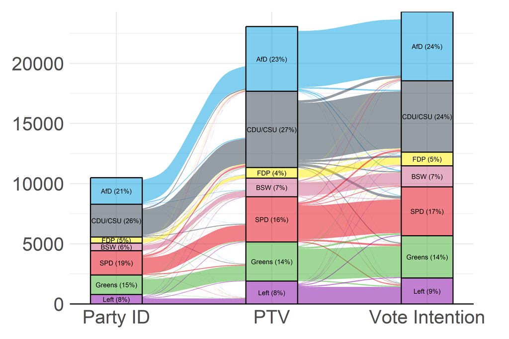

```r
party_order_federal <- c("AfD", "CDU/CSU", "FDP", "BSW", "SPD", "Greens", "Left")

plot_alluvial_federal <- plot_pref_flow(pref_measures_federal, party_order_federal) # helper
plot_alluvial_federal
```

```r
save_figure(plot_alluvial_federal, "figure_B3_desc_pref_comparison_federal",
  election = "federal", # helper
  width = "landscape", aspect = 6 / 10
)
```

# Response Times (Figures B.1, B.2)

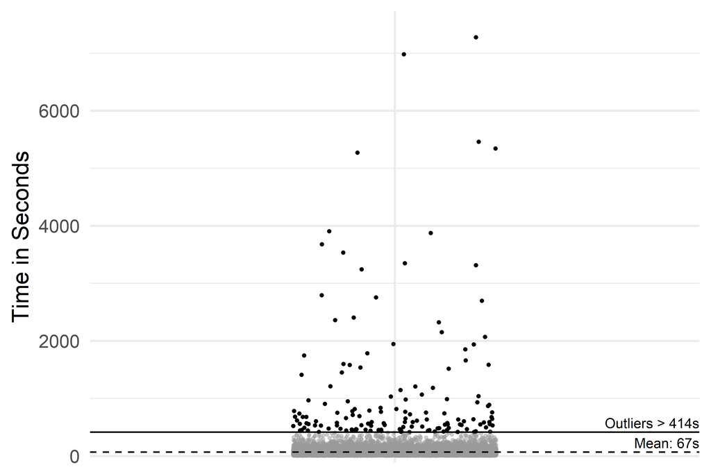

```r
plot_response_times_outliers_federal <- plot_time_outliers(data_federal_time_main, t_mean_federal, t_threshold_upper_federal) # helper
plot_response_times_outliers_federal
```

```r
save_figure(plot_response_times_outliers_federal, "figure_B1a_desc_time_dist_federal",
  election = "federal", # helper
  width = "subfigure", aspect = 6 / 8
)
```

Response times in seconds and logged (dependent variable of H1), without outliers.

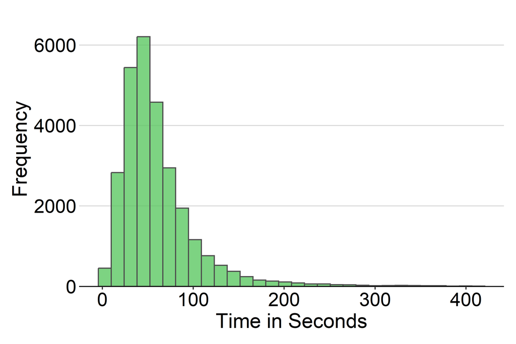

```r
plot_response_times_s_federal <- plot_time_hist(data_federal_time_main_nooutliers, "t_list_votes_exp_Page_Submit", # helper
  "Time in Seconds",
  election = "federal"
)
plot_response_times_log_federal <- plot_time_hist(data_federal_time_main_nooutliers, "t_list_votes_exp_Page_Submit_log", # helper
  "log(seconds)",
  election = "federal"
)
plot_response_times_s_federal
```

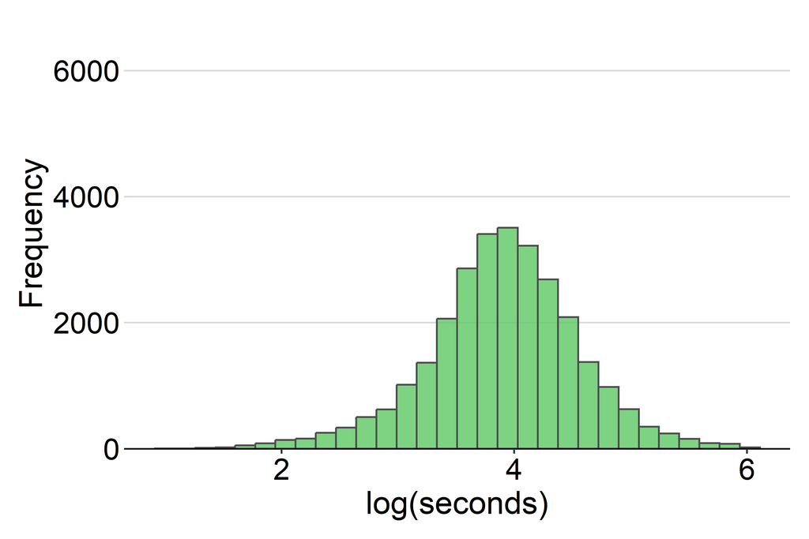

```r
plot_response_times_log_federal
```

```r
save_figure(plot_response_times_s_federal, "figure_B2a_desc_time_hist_federal",
  election = "federal", # helper
  width = "subfigure", aspect = 6 / 8
)
save_figure(plot_response_times_log_federal, "figure_B2b_desc_time_loghist_federal",
  election = "federal", # helper
  width = "subfigure", aspect = 6 / 8
)
```

# Vote Share Expectations (Figure 1, Table B.5)

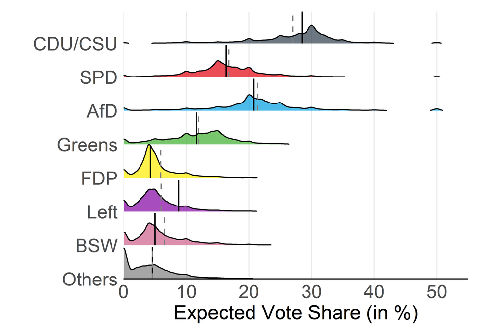

```r
plot_voteshare_dist_federal <- plot_vote_share_dist(data_federal_long_main, election = "federal") # helper
save_figure(plot_voteshare_dist_federal, "figure_1a_desc_voteshare_dist_federal",
  election = "federal", # helper
  width = "half", aspect = 8 / 12
)
plot_voteshare_dist_federal
```

Spread of the individual expectations per party (paper section Data).

```r
data_federal_long_main %>%
  group_by(party) %>%
  summarize(result = first(list_votes_result), mean = mean(list_votes_exp), sd = sd(list_votes_exp)) %>%
  arrange(sd) %>%
  print_values(digits = 2) # helper
```

```
   party result  mean   sd
     FDP   4.33  5.85 4.89
  Others   4.57  4.60 5.34
    Left   8.77  5.98 5.38
     BSW   4.98  6.48 5.76
  Greens  11.61 12.00 6.19
     SPD  16.41 16.79 6.88
 CDU/CSU  28.52 26.95 7.83
     AfD  20.80 21.35 8.55
```

Mean, deviation from the result and SD per party, overall and by group.

```r
accuracy_table_data_federal <- compute_accuracy_by_group(data_federal_long_main, "all", election = "federal") %>% # helper
  left_join(compute_accuracy_by_group(filter(data_federal_long_main, treatment == "Control"), "c", election = "federal"), # helper
    by = c("party", "list_votes_result")
  ) %>%
  left_join(compute_accuracy_by_group(filter(data_federal_long_main, treatment == "Treatment (5)"), "t5", election = "federal"), # helper
    by = c("party", "list_votes_result")
  ) %>%
  left_join(compute_accuracy_by_group(filter(data_federal_long_main, treatment == "Treatment (500)"), "t500", election = "federal"), # helper
    by = c("party", "list_votes_result")
  ) %>%
  arrange(party)

write_accuracy_table( # helper
  accuracy_table_data_federal,
  groups  = c(all = "Full Sample", c = "Control", t5 = "Treatment (5)", t500 = "Treatment (500)"),
  caption = "Forecasting Accuracy by Party and Treatment Group (Federal)",
  label   = "tab:accuracy_federal",
  note    = note_accuracy,
  file    = "output/tables/table_B5_accuracy_federal.tex"
)
```

Forecasting Accuracy by Party and Treatment Group (Federal)

| Party | Result | Full Sample Mean | Full Sample Dev.<sup>1</sup> | Full Sample SD | Control Avg. | Control Dev. | Control SD | Treatment (5) Avg. | Treatment (5) Dev. | Treatment (5) SD | Treatment (500) Avg. | Treatment (500) Dev. | Treatment (500) SD |
| --- | --- | --- | --- | --- | --- | --- | --- | --- | --- | --- | --- | --- | --- |
| AfD | 20.80 | 21.35 | 0.55 | 8.55 | 21.29 | 0.48 | 8.95 | 21.34 | 0.54 | 8.48 | 21.42 | 0.62 | 8.21 |
| BSW | 4.98 | 6.48 | 1.50 | 5.76 | 6.62 | 1.63 | 6.05 | 6.37 | 1.39 | 5.63 | 6.44 | 1.46 | 5.60 |
| CDU/CSU | 28.52 | 26.95 | −1.57 | 7.83 | 26.74 | −1.78 | 8.02 | 26.93 | −1.59 | 7.78 | 27.18 | −1.34 | 7.69 |
| FDP | 4.33 | 5.85 | 1.53 | 4.89 | 6.01 | 1.68 | 5.21 | 5.87 | 1.54 | 4.80 | 5.69 | 1.36 | 4.66 |
| Greens | 11.61 | 12.00 | 0.39 | 6.19 | 11.90 | 0.29 | 6.31 | 12.10 | 0.49 | 6.20 | 12.00 | 0.40 | 6.04 |
| Left | 8.77 | 5.98 | −2.80 | 5.38 | 5.99 | −2.78 | 5.36 | 6.05 | −2.73 | 5.55 | 5.89 | −2.88 | 5.21 |
| SPD | 16.41 | 16.79 | 0.38 | 6.88 | 16.69 | 0.28 | 7.04 | 16.80 | 0.39 | 6.78 | 16.88 | 0.46 | 6.82 |
| Others | 4.57 | 4.60 | 0.03 | 5.34 | 4.77 | 0.20 | 5.71 | 4.54 | −0.03 | 5.14 | 4.49 | −0.08 | 5.14 |
| MAE |  |  | 1.09 |  |  | 1.14 |  |  | 1.09 |  |  | 1.08 |  |
| RMSE |  |  | 1.39 |  |  | 1.45 |  |  | 1.37 |  |  | 1.36 |  |

<sup>1</sup> Dev. = Mean - Result. The mean of the individual expectations equals the citizen forecast. The 'MAE' / 'RMSE' rows give the accuracy of these group-level vote share forecasts.

# Forecast Error for the Preferred Party (Figure B.5)

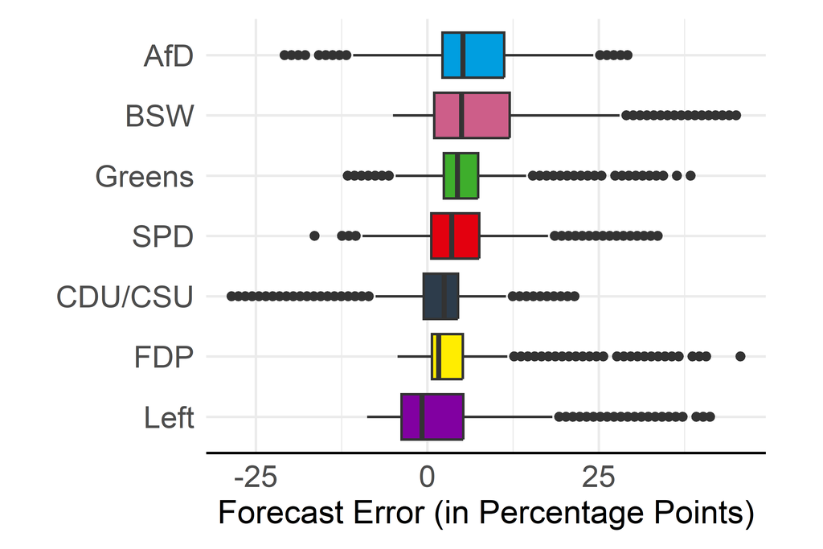

```r
plot_pref_boxplot_federal <- plot_pref_boxplot(data_federal_prefparty_ptv_main) # helper
plot_pref_boxplot_federal
```

```r
save_figure(plot_pref_boxplot_federal, "figure_B5_desc_pref_boxplot_ptv_federal",
  election = "federal", # helper
  width = "boxplot", aspect = 6 / 8
)
```

Note of Figure B.5: preferred parties, share underestimating them, and observed and possible range of the forecast error (sliders from 0 to 50).

```r
data_federal_prefparty_ptv_main %>%
  group_by(party) %>%
  summarize(
    n = n(), pct_underestimated = 100 * mean(list_votes_exp_diff < 0),
    observed_min = min(list_votes_exp_diff), observed_max = max(list_votes_exp_diff),
    possible_min = -first(list_votes_result), possible_max = 50 - first(list_votes_result),
    .groups = "drop"
  ) %>%
  mutate(pct_respondents = 100 * n / sum(n)) %>%
  arrange(desc(n)) %>%
  print_values(digits = 1) # helper
```

```
   party    n pct_underestimated observed_min observed_max possible_min possible_max pct_respondents
 CDU/CSU 6337               26.7        -28.5         21.5        -28.5         21.5            27.5
     AfD 5375               11.9        -20.8         29.2        -20.8         29.2            23.3
     SPD 3760               24.3        -16.4         33.6        -16.4         33.6            16.3
  Greens 3247               10.4        -11.6         38.4        -11.6         38.4            14.1
    Left 1907               54.4         -8.8         41.2         -8.8         41.2             8.3
     BSW 1551               12.1         -5.0         45.0         -5.0         45.0             6.7
     FDP  879               19.1         -4.3         45.7         -4.3         45.7             3.8
```

Share underestimating the preferred party, overall (%).

```r
data_federal_prefparty_ptv_main %>%
  summarize(pct_underestimated = 100 * mean(list_votes_exp_diff < 0))
```

```
# A tibble: 1 × 1
  pct_underestimated
               <dbl>
1               21.6
```

Highest PTV score of the preferred party.

```r
data_federal_ptv_main %>%
  filter(preferred_party_ptv_dummy == 1) %>%
  count(ptv_score) %>%
  mutate(pct = 100 * n / sum(n)) %>%
  arrange(desc(ptv_score)) %>%
  print_values(digits = 2) # helper
```

```
 ptv_score    n   pct
        11 9299 40.33
        10 5109 22.16
         9 3760 16.31
         8 2616 11.35
         7 1107  4.80
         6  610  2.65
         5  330  1.43
         4  133  0.58
         3   69  0.30
         2   21  0.09
         1    2  0.01
```

# Save for the Analysis

The analysis data sets are saved to `data/processed/`, one file per data set.

```r
save(data_federal_main,                 file = "data/processed/data_federal_main.rdata")
save(data_federal_noexcl,               file = "data/processed/data_federal_noexcl.rdata")
save(data_federal_time_main_nooutliers, file = "data/processed/data_federal_time_main_nooutliers.rdata")
save(data_federal_time_noexcl,          file = "data/processed/data_federal_time_noexcl.rdata")
save(data_federal_ptv_main,             file = "data/processed/data_federal_ptv_main.rdata")
save(data_federal_ptv_noexcl,           file = "data/processed/data_federal_ptv_noexcl.rdata")
save(data_federal_ptvties_main,         file = "data/processed/data_federal_ptvties_main.rdata")
save(data_federal_ptvties_noexcl,       file = "data/processed/data_federal_ptvties_noexcl.rdata")
save(data_federal_ptvscore_main,        file = "data/processed/data_federal_ptvscore_main.rdata")
save(data_federal_ptvscore_noexcl,      file = "data/processed/data_federal_ptvscore_noexcl.rdata")
save(data_federal_vi_main,              file = "data/processed/data_federal_vi_main.rdata")
save(data_federal_vi_noexcl,            file = "data/processed/data_federal_vi_noexcl.rdata")
save(data_federal_pid_main,             file = "data/processed/data_federal_pid_main.rdata")
save(data_federal_pid_noexcl,           file = "data/processed/data_federal_pid_noexcl.rdata")
```